# Cheese Analysis

### Creating a facet plot

Now I want to create a facet plot for all cheese types over all the years in my data set, to give my readers a comprehensive look at prices.

```r
facet_adj <- chs_with_avg |>
  group_by(yr, type) |>
  summarize(total_price_adj) |>
  group_by(yr, type) |>
  summarize(adj_yearly_price = mean(total_price_adj)) |>
  arrange()
```

```
## argument.
```

```r
facet_adj
```

| yr | type | adj_yearly_price |
| --- | --- | --- |
| 2000 | BLUE | 3.088903 |
| 2000 | BRICK | 2.519478 |
| 2000 | CHEDDAR | 2.174563 |
| 2000 | MONTEREY JACK | 2.786599 |
| 2000 | MOZZARELLA | 2.931377 |
| 2000 | MUENSTER | 2.327261 |
| 2000 | PROCESS AMERICAN | 2.230838 |
| 2000 | SWISS | 3.745188 |
| 2001 | BLUE | 3.530847 |
| 2001 | BRICK | 2.924318 |

[output cut: 174 more lines]

Now I’ll create the separate line plot for my inflation adjusted price data.

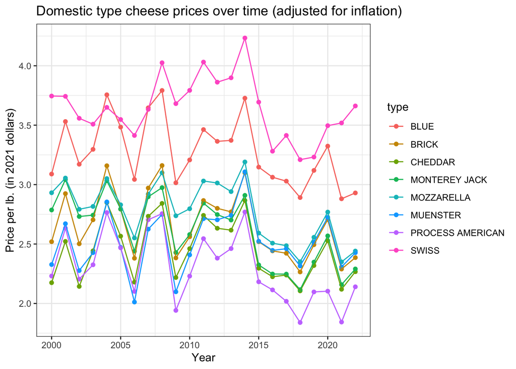

```r
separate_plot <- ggplot(facet_adj, aes(x = yr, y = adj_yearly_price)) +
  theme_bw() +
  geom_point(aes(color = type)) +
  geom_line(aes(color = type)) +
  labs(title = "Domestic type cheese prices over time (adjusted for inflation)",
       x = "Year", y = "Price per lb. (in 2021 dollars)")

separate_plot
```

### Inflation adjusted facet plot (FOR MY STORY)

Now I’ll create the facet plot, which will separate the graphs by cheese type to show prices over time for each type of cheese.

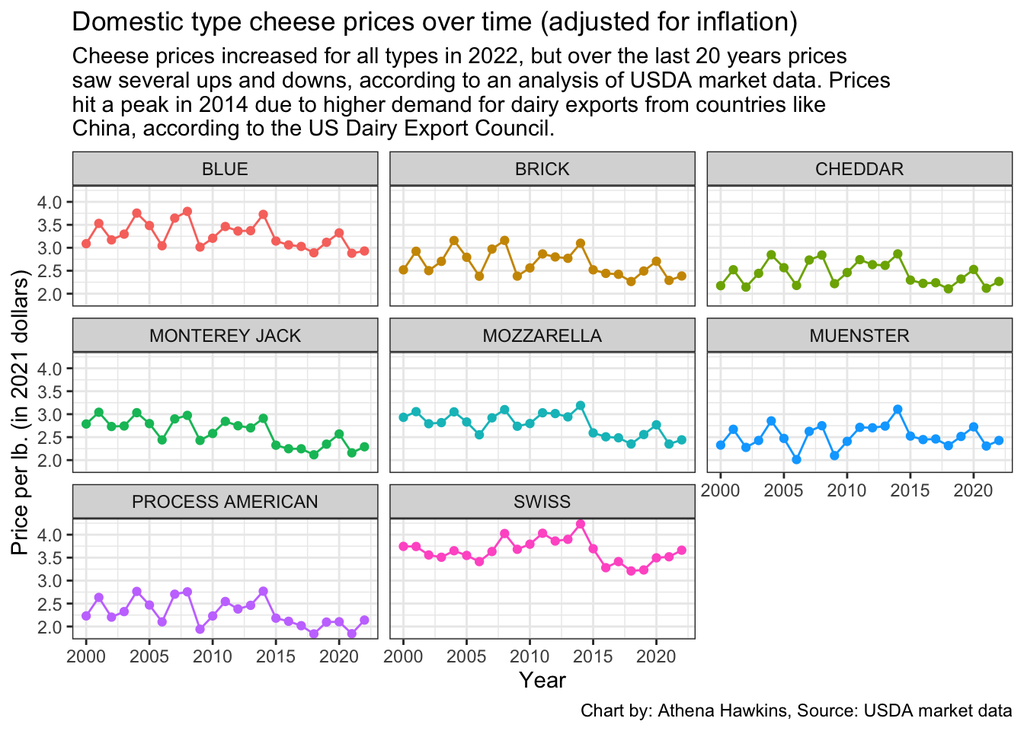

```r
facet_plot <- separate_plot +
  facet_wrap(~ type) +
  theme_bw() +
  theme(legend.position = "none") +
  labs(title = "Domestic type cheese prices over time (adjusted for inflation)", subtitle = str_wrap("Cheese prices increased for all types in 2022, but over the last 20 years prices saw several ups and downs, according to an analysis of USDA market data. Prices hit a peak in 2014 due to higher demand for dairy exports from countries like China, according to the US Dairy Export Council."), caption = "Chart by: Athena Hawkins, Source: USDA market data",
       x = "Year", y = "Price per lb. (in 2021 dollars)")

facet_plot
```

### Facet Wrap All Cheeses, Not Adjusted

Just for fun, I want to see what the data would look like if I used my unadjusted numbers for the graphs.

```r
unadj <- chs_with_avg |>
  group_by(yr, type) |>
  summarize(total_avg_price) |>
  group_by(yr, type) |>
  summarize(unadj_price = mean(total_avg_price)) |>
  arrange()
```

```
## argument.
```

```r
unadj
```

| yr | type | unadj_price |
| --- | --- | --- |
| 2000 | BLUE | 1.962764 |
| 2000 | BRICK | 1.600937 |
| 2000 | CHEDDAR | 1.381770 |
| 2000 | MONTEREY JACK | 1.770673 |
| 2000 | MOZZARELLA | 1.862668 |
| 2000 | MUENSTER | 1.478798 |
| 2000 | PROCESS AMERICAN | 1.417529 |
| 2000 | SWISS | 2.379784 |
| 2001 | BLUE | 2.307428 |
| 2001 | BRICK | 1.911058 |

[output cut: 174 more lines]

I’ll put together the separate line plot here.

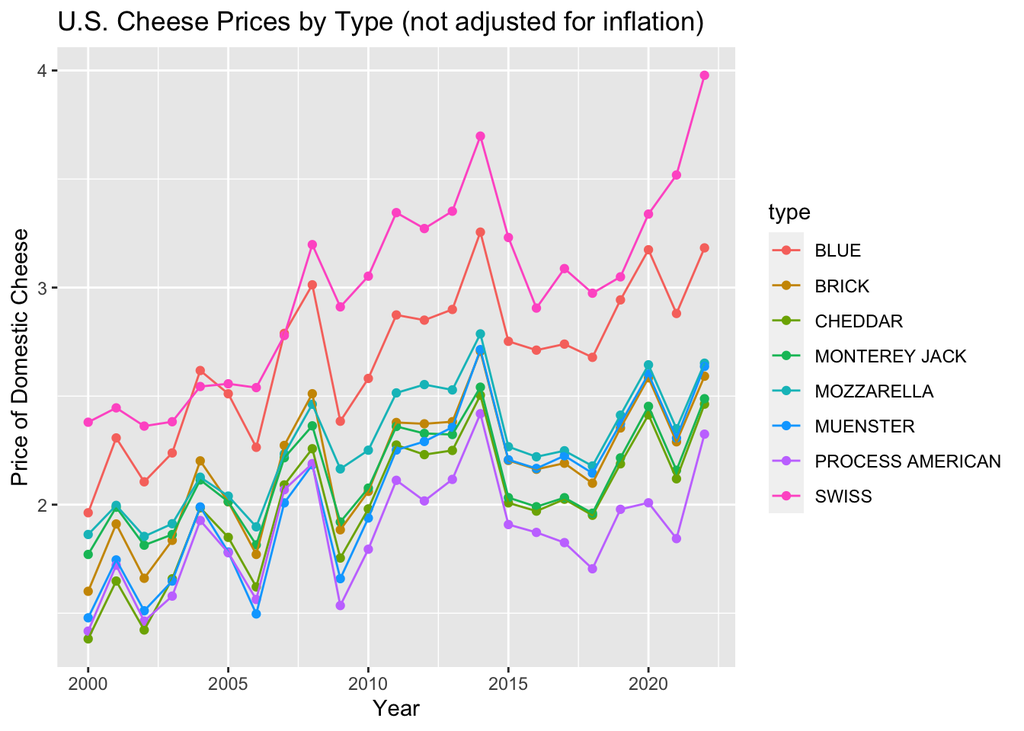

```r
unadj_plot <- ggplot(unadj, aes(x = yr, y = unadj_price)) +
  geom_point(aes(color = type)) +
  geom_line(aes(color = type)) +
  labs(title = "U.S. Cheese Prices by Type (not adjusted for inflation)",
       x = "Year", y = "Price of Domestic Cheese")

unadj_plot
```

Now I’ll split it into individual plots.

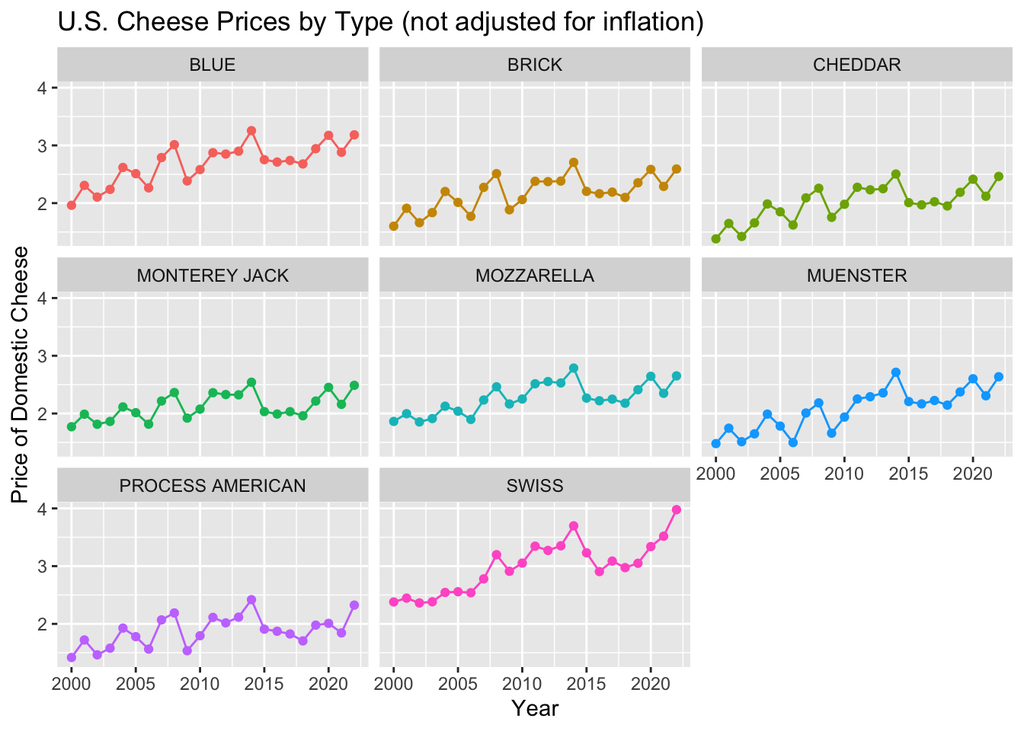

```r
unadj_facet <- unadj_plot +
  facet_wrap(~ type) +
  theme(legend.position = "none")

unadj_facet
```

## Save plots

This will save the plots to my project folder as pdfs so I can look at the full scale.

```r
ggsave("thisyearprices.pdf", plot=thisyear_plot, width=12, height=8)
```

```r
ggsave("facetprices.pdf", plot=facet_plot, width=12, height=8)
```

```r
ggsave("yearlystorage.pdf", plot=yearly_storage_plot, width=12, height=8)
```

## Lede and nut graph draft

The U.S. government’s stockpile of cheese reached nearly 1.5 billion pounds this year. The amount of cheese in cold storage across the country has more than doubled since 2001, according to an analysis USDA holdings data.

Government cheese holdings increased by over 2.8 percent this year, marking the eighth consecutive year in which the stockpile grew. This year’s hike came amid rising prices for all types of domestic cheese, even after accounting for steep levels of inflation. But the federal government is no stranger to propping up dairy farmers amid economic uncertainty — their ever-growing cheese storage originated from another inflationary period in the 1970s.